# Time Series Processing

# Introduction

Google Trends gives us an estimate of search volume. Let's explore if search popularity relates to other kinds of data. Perhaps there are patterns in Google's search volume and the price of Bitcoin or a hot stock like Tesla. Perhaps search volume for the term "Unemployment Benefits" can tell us something about the actual unemployment rate?

Data Sources:

- [Unemployment Rate from FRED](https://fred.stlouisfed.org/series/UNRATE/)
- [Google Trends](https://trends.google.com/trends/explore)
- [Yahoo Finance for Tesla Stock Price](https://finance.yahoo.com/quote/TSLA/history?p=TSLA)
- [Yahoo Finance for Bitcoin Stock Price](https://finance.yahoo.com/quote/BTC-USD/history?p=BTC-USD)

```python
import pandas as pd
import matplotlib.pyplot as plt

df_tesla = pd.read_csv('data/TESLA Search Trend vs Price.csv')
df_btc_search = pd.read_csv('data/Bitcoin Search Trend.csv')
df_btc_price = pd.read_csv('data/Daily Bitcoin Price.csv')
df_unemployment = pd.read_csv('data/UE Benefits Search vs UE Rate 2004-19.csv')
```

# Data Exploration

**Challenge**:

- What are the shapes of the dataframes?
- What are the column names?
- Complete the f-string to show the largest/smallest number in the search data column
  - Largest value for Tesla in Web Search: print(f’Largest value for Tesla in Web Search: ’)
  - Smallest value for Tesla in Web Search: print(f’Smallest value for Tesla in Web Search: ’)
- Try the `.describe()` function to see some useful descriptive statistics
- What is the periodicity of the time series data (daily, weekly, monthly)?
- What does a value of 100 in the Google Trend search popularity actually mean?

All web search values are relative to the maximum in the data itself. Thus, a 100 means that day the search for the term attained the maximum of the time window analyzed. A 20 means that that day the number of searches was 20% of the searches made in the day of the maximum.

## Tesla

```python
# + What are the shapes of the dataframes?
print(f"The data frame is {df_tesla.shape}.")

# + What are the column names?
print(f"The columns of this data frame are: {list(df_tesla.columns)}")

# + Complete the f-string to show the largest/smallest number in the search data column
#     + Largest value for Tesla in Web Search: print(f'Largest value for Tesla in Web Search: ')
max_web_search = df_tesla['TSLA_WEB_SEARCH'].idxmax()
print(f"The largest value in Web search was {df_tesla['TSLA_WEB_SEARCH'][max_web_search]}, and was on {df_tesla['MONTH'][max_web_search]}")

#     + Smallest value for Tesla in Web Search: print(f'Smallest value for Tesla in Web Search: ')
min_web_search = df_tesla['TSLA_WEB_SEARCH'].idxmin()
print(f"The smallest value in Web search was {df_tesla['TSLA_WEB_SEARCH'][min_web_search]}, and was on {df_tesla['MONTH'][min_web_search]}")

# + Try the `.describe()` function to see some useful descriptive statistics
print(df_tesla.describe())

# + What is the periodicity of the time series data (daily, weekly, monthly)? see https://pandas.pydata.org/pandas-docs/stable/user_guide/timeseries.html#offset-aliases
df_tesla.MONTH = pd.to_datetime(df_tesla.MONTH)
print(f"The frequency of the data is {df_tesla.MONTH.dt.freq}, which means 'month at start'.")
```

```
The data frame is (124, 3).
The columns of this data frame are: ['MONTH', 'TSLA_WEB_SEARCH', 'TSLA_USD_CLOSE']
The largest value in Web search was 31, and was on 2020-09-01
The smallest value in Web search was 2, and was on 2010-08-01
       TSLA_WEB_SEARCH  TSLA_USD_CLOSE
count       124.000000      124.000000
mean          8.725806       50.962145
std           5.870332       65.908389
min           2.000000        3.896000
25%           3.750000        7.352500
50%           8.000000       44.653000
75%          12.000000       58.991999
max          31.000000      498.320007
The frequency of the data is MS, which means 'month at start'.
```

## Unemployment Data

```python
# + What are the shapes of the dataframes?
print(f"The data frame is {df_unemployment.shape}.")

# + What are the column names?
print(f"The columns of this data frame are: {list(df_unemployment.columns)}")

# + Complete the f-string to show the largest/smallest number in the search data column
#     + Largest value for Tesla in Web Search: print(f'Largest value for Tesla in Web Search: ')
max_web_search = df_unemployment['UE_BENEFITS_WEB_SEARCH'].idxmax()
print(f"The largest value in Web search was {df_unemployment['UE_BENEFITS_WEB_SEARCH'][max_web_search]}, and was on {df_unemployment['MONTH'][max_web_search]}")

#     + Smallest value for Tesla in Web Search: print(f'Smallest value for Tesla in Web Search: ')
min_web_search = df_unemployment['UE_BENEFITS_WEB_SEARCH'].idxmin()
print(f"The smallest value in Web search was {df_unemployment['UE_BENEFITS_WEB_SEARCH'][min_web_search]}, and was on {df_unemployment['MONTH'][min_web_search]}")

# + Try the `.describe()` function to see some useful descriptive statistics
print(df_unemployment.describe())

# + What is the periodicity of the time series data (daily, weekly, monthly)? see https://pandas.pydata.org/pandas-docs/stable/user_guide/timeseries.html#offset-aliases
df_unemployment.MONTH = pd.to_datetime(df_unemployment.MONTH)
print(f"The frequency of the data is {df_unemployment.MONTH.dt.freq}, which means 'month at start'.")
```

```
The data frame is (181, 3).
The columns of this data frame are: ['MONTH', 'UE_BENEFITS_WEB_SEARCH', 'UNRATE']
The largest value in Web search was 100, and was on 2009-02
The smallest value in Web search was 14, and was on 2018-05
       UE_BENEFITS_WEB_SEARCH      UNRATE
count              181.000000  181.000000
mean                35.110497    6.217680
std                 20.484925    1.891859
min                 14.000000    3.700000
25%                 21.000000    4.700000
50%                 26.000000    5.400000
75%                 45.000000    7.800000
max                100.000000   10.000000
The frequency of the data is MS, which means 'month at start'.
```

## Bitcoin

```python
# + What are the shapes of the dataframes?
print(f"The data frame is {df_btc_search.shape}.")

# + What are the column names?
print(f"The columns of this data frame are: {list(df_btc_search.columns)}")

# + Complete the f-string to show the largest/smallest number in the search data column
#     + Largest value for Tesla in Web Search: print(f'Largest value for Tesla in Web Search: ')
max_web_search = df_btc_search['BTC_NEWS_SEARCH'].idxmax()
print(f"The largest value in Web search was {df_btc_search['BTC_NEWS_SEARCH'][max_web_search]}, and was on {df_btc_search['MONTH'][max_web_search]}")

#     + Smallest value for Tesla in Web Search: print(f'Smallest value for Tesla in Web Search: ')
min_web_search = df_btc_search['BTC_NEWS_SEARCH'].idxmin()
print(f"The smallest value in Web search was {df_btc_search['BTC_NEWS_SEARCH'][min_web_search]}, and was on {df_btc_search['MONTH'][min_web_search]}")

# + Try the `.describe()` function to see some useful descriptive statistics
print(df_btc_search.describe())

# + What is the periodicity of the time series data (daily, weekly, monthly)? see https://pandas.pydata.org/pandas-docs/stable/user_guide/timeseries.html#offset-aliases
df_btc_search.MONTH = pd.to_datetime(df_btc_search.MONTH)
print(f"The frequency of the data is {df_btc_search.MONTH.dt.freq}, which means 'month at start'.")
```

```
The data frame is (73, 2).
The columns of this data frame are: ['MONTH', 'BTC_NEWS_SEARCH']
The largest value in Web search was 100, and was on 2017-12
The smallest value in Web search was 3, and was on 2015-04
       BTC_NEWS_SEARCH
count        73.000000
mean         15.013699
std          15.146959
min           3.000000
25%           5.000000
50%          14.000000
75%          18.000000
max         100.000000
The frequency of the data is MS, which means 'month at start'.
```

# Data Cleaning

## Check for Missing Values

**Challenge**: Are there any missing values in any of the dataframes? If so, which row/rows have missing values? How many missing values are there?

Missing values for Tesla?:

```python
from IPython.display import Markdown, display

display(Markdown(df_tesla.isna().sum().to_markdown(index = True)))
```

|  | 0 |
| --- | --- |
| MONTH | 0 |
| TSLA_WEB_SEARCH | 0 |
| TSLA_USD_CLOSE | 0 |

Missing values for U/E?:

```python
display(Markdown(df_unemployment.isna().sum().to_markdown(index = True)))
```

|  | 0 |
| --- | --- |
| MONTH | 0 |
| UE_BENEFITS_WEB_SEARCH | 0 |
| UNRATE | 0 |

Missing values for BTC Search?:

```python
display(Markdown(df_btc_search.isna().sum().to_markdown(index = True)))
```

|  | 0 |
| --- | --- |
| MONTH | 0 |
| BTC_NEWS_SEARCH | 0 |

v Missing values for BTC price?:

```python
display(Markdown(df_btc_price.isna().sum().to_markdown(index = True)))
```

|  | 0 |
| --- | --- |
| DATE | 0 |
| CLOSE | 1 |
| VOLUME | 1 |

**Challenge**: Remove any missing values that you found.

```python
df_btc_price.dropna(inplace = True)
```

## Convert Strings to DateTime Objects

**Challenge**: Check the data type of the entries in the DataFrame MONTH or DATE columns. Convert any strings in to Datetime objects. Do this for all 4 DataFrames. Double check if your type conversion was successful.

```python
# It was already done for all data frames, except btc_price
df_btc_price.DATE = pd.to_datetime(df_btc_price.DATE)
print(df_btc_price.DATE.dtypes)
```

```
datetime64[ns]
```

## Converting from Daily to Monthly Data

[Pandas .resample() documentation](https://pandas.pydata.org/pandas-docs/stable/reference/api/pandas.DataFrame.resample.html)

```python
df_btc_price.set_index("DATE", inplace = True)
resampled_btc_price = df_btc_price.resample("MS").mean()
```

# Data Visualisation

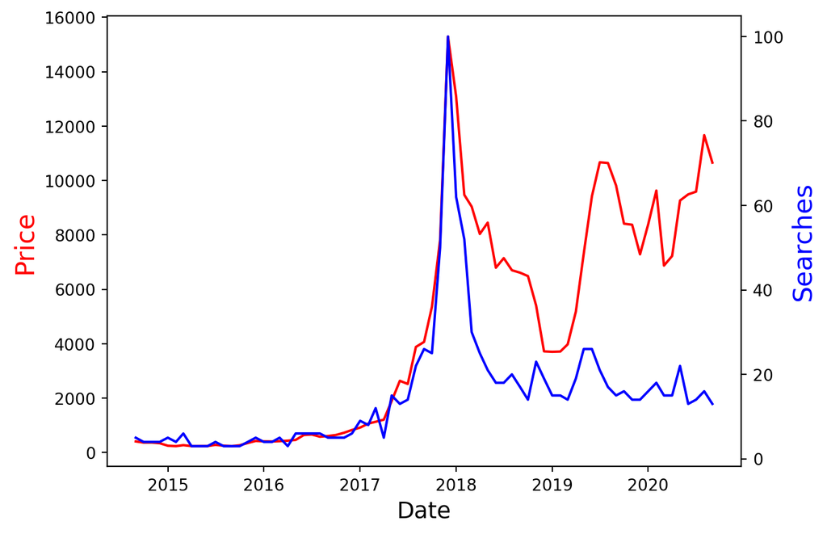

```python
#define subplots
fig,ax = plt.subplots()

#add first line to plot
ax.plot(resampled_btc_price.index.to_numpy(), resampled_btc_price.CLOSE.to_numpy(), color="red")

#add x-axis label
ax.set_xlabel('Date', fontsize=14)

#add y-axis label
ax.set_ylabel('Price', color="red", fontsize=16)

#define second y-axis that shares x-axis with current plot
ax2 = ax.twinx()

#add second line to plot
ax2.plot(df_btc_search.MONTH.to_numpy(), df_btc_search.BTC_NEWS_SEARCH.to_numpy(), color="blue")

#add second y-axis label
ax2.set_ylabel('Searches', color="blue", fontsize=16)

fig.show()
```

# Create locators for ticks on the time axis

```python
import matplotlib.dates as mdates

years = mdates.YearLocator()
months = mdates.MonthLocator()
years_fmt = mdates.DateFormatter("%Y")
```

### Tesla Stock Price v.s. Search Volume

**Challenge:** Plot the Tesla stock price against the Tesla search volume using a line chart and two different axes. Label one axis `TSLA Stock Price` and the other `Search Trend`.

**Challenge**: Add colours to style the chart. This will help differentiate the two lines and the axis labels.

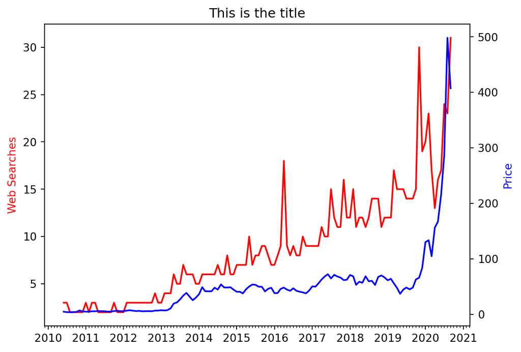

Tesla Stock Price and Search Volume

```python
fig, ax1 = plt.subplots()
ax2 = ax1.twinx()

ax1.plot(df_tesla.MONTH.to_numpy(), df_tesla.TSLA_WEB_SEARCH.to_numpy(), color = "red")
ax1.set_ylabel("Web Searches", color = "red")

ax2.plot(df_tesla.MONTH.to_numpy(), df_tesla.TSLA_USD_CLOSE.to_numpy(), color = "blue")
ax2.set_ylabel("Price", color = "blue")

ax1.xaxis.set_major_formatter(years_fmt)
ax1.xaxis.set_major_locator(years)
ax1.xaxis.set_minor_locator(months)

plt.title("This is the title")

plt.show()
```

## Bitcoin (BTC) Price v.s. Search Volume

**Challenge**: Create the same chart for the Bitcoin Prices vs. Search volumes.

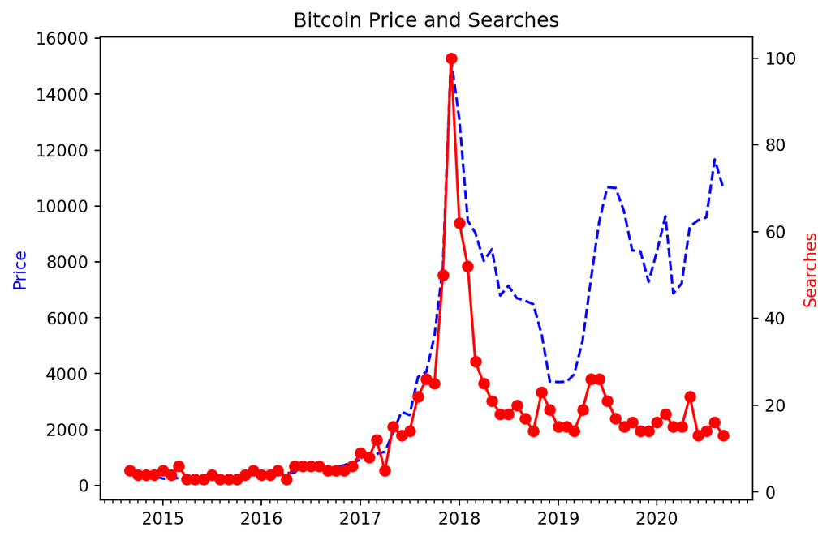

Bitcoin Searches and Price comparisson

```python
df_btc_search.set_index("MONTH", inplace = True)
merged_btc = pd.merge(resampled_btc_price, df_btc_search, right_index = True, left_index = True)

fig, ax1 = plt.subplots()
ax2 = ax1.twinx()

ax1.plot(merged_btc.index.to_numpy(), merged_btc.CLOSE.to_numpy(), color = "blue", linestyle = "dashed")
ax1.set_ylabel("Price", color = "blue")

ax2.plot(merged_btc.index.to_numpy(), merged_btc.BTC_NEWS_SEARCH.to_numpy(), color = "red", marker = "o")
ax2.set_ylabel("Searches", color = "red")

ax1.xaxis.set_major_formatter(years_fmt)
ax1.xaxis.set_major_locator(years)
ax1.xaxis.set_minor_locator(months)

plt.title("Bitcoin Price and Searches")
plt.show()
```

## Unemployement Benefits Search vs. Actual Unemployment in the U.S.

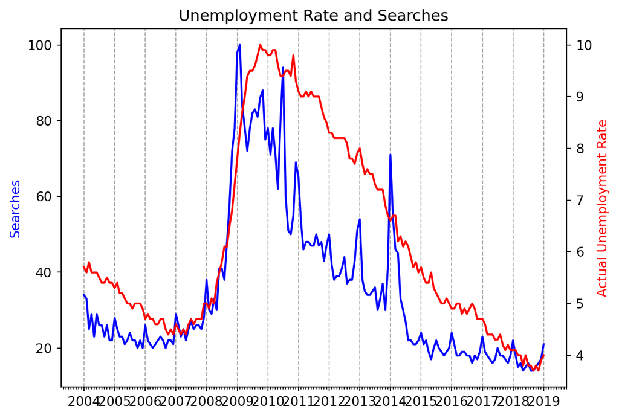

Unemployment Searches and Actual Level

```python
fig, ax1 = plt.subplots()
ax2 = ax1.twinx()

ax1.plot(df_unemployment.MONTH.to_numpy(), df_unemployment.UE_BENEFITS_WEB_SEARCH.to_numpy(), color = "blue")
ax1.set_ylabel("Searches", color = "blue")

ax2.plot(df_unemployment.MONTH.to_numpy(), df_unemployment.UNRATE.to_numpy(), color = "red")
ax2.set_ylabel("Actual Unemployment Rate", color = "red")

ax1.xaxis.set_major_formatter(years_fmt)
ax1.xaxis.set_major_locator(years)
ax1.xaxis.set_minor_locator(months)

ax1.grid(axis = "x", which = "major", linestyle = "dashed")
plt.title("Unemployment Rate and Searches")
plt.show()
```

**Challenge**: Calculate the 3-month or 6-month rolling average for the web searches. Plot the 6-month rolling average search data against the actual unemployment. What do you see in the chart? Which line moves first?

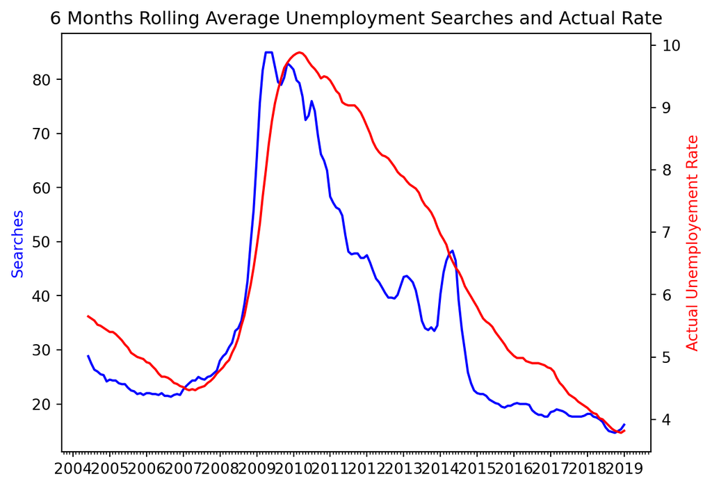

6 months moving average unemployment data

```python
df_unemployment.set_index("MONTH", inplace = True)
unemployment_rolling = df_unemployment.rolling(window = 6).mean()

fig, ax1 = plt.subplots()
ax2 = ax1.twinx()

ax1.plot(unemployment_rolling.index.to_numpy(), unemployment_rolling.UE_BENEFITS_WEB_SEARCH.to_numpy(), color = "blue")
ax1.set_ylabel("Searches", color = "blue")

ax2.plot(unemployment_rolling.index.to_numpy(), unemployment_rolling.UNRATE.to_numpy(), color = "red")
ax2.set_ylabel("Actual Unemployement Rate", color = "red")

ax1.xaxis.set_major_formatter(years_fmt)
ax1.xaxis.set_major_locator(years)
ax1.xaxis.set_minor_locator(months)

plt.title("6 Months Rolling Average Unemployment Searches and Actual Rate")
plt.show()
```

## Including 2020 in Unemployment Charts

**Challenge**: Read the data in the `UE Benefits Search vs UE Rate 2004-20.csv` into a DataFrame. Convert the MONTH column to Pandas Datetime objects and then plot the chart. What do you see?

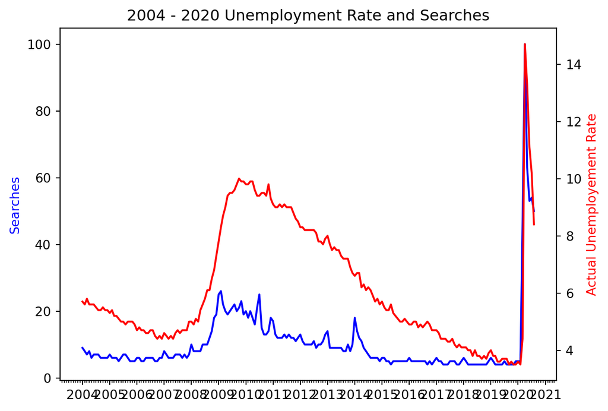

```python
ue_2020 = pd.read_csv("data/UE Benefits Search vs UE Rate 2004-20.csv")
ue_2020.MONTH = pd.to_datetime(ue_2020.MONTH)
ue_2020.set_index("MONTH", inplace = True)

fig, ax1 = plt.subplots()
ax2 = ax1.twinx()

ax1.plot(ue_2020.index.to_numpy(), ue_2020.UE_BENEFITS_WEB_SEARCH.to_numpy(), color = "blue")
ax1.set_ylabel("Searches", color = "blue")

ax2.plot(ue_2020.index.to_numpy(), ue_2020.UNRATE.to_numpy(), color = "red")
ax2.set_ylabel("Actual Unemployement Rate", color = "red")

ax1.xaxis.set_major_formatter(years_fmt)
ax1.xaxis.set_major_locator(years)
ax1.xaxis.set_minor_locator(months)

plt.title("2004 - 2020 Unemployment Rate and Searches")
plt.show()
```